# Trabalho_R

# Pergunta 1 – Classificação das Variáveis

Nesta etapa, procedeu-se à classificação técnica de todas as variáveis presentes na base de dados, identificando a sua natureza e a respetiva escala de medição. Esta classificação é fundamental para selecionar os métodos estatísticos e as representações gráficas mais adequadas.

| Variável | Tipo de Variável | Escala de Medição |
| --- | --- | --- |
| **Name** | Qualitativa Nominal | Nominal |
| **Age** | Quantitativa Discreta | Razão |
| **Gender** | Qualitativa Nominal | Nominal |
| **Blood Type** | Qualitativa Nominal | Nominal |
| **Medical Condition** | Qualitativa Nominal | Nominal |
| **Date of Admission** | Quantitativa Discreta (temporal) | Intervalo |
| **Doctor / Hospital** | Qualitativa Nominal | Nominal |
| **Insurance Provider** | Qualitativa Nominal | Nominal |
| **Billing Amount** | Quantitativa Contínua | Razão |
| **Room Number** | Qualitativa Nominal | Nominal |
| **Admission Type** | Qualitativa Nominal | Nominal |
| **Discharge Date** | Quantitativa Discreta (temporal) | Intervalo |
| **Medication** | Qualitativa Nominal | Nominal |
| **Test Results** | Qualitativa Nominal | Nominal |

# Pergunta 2 -Caracterização de variáveis

*2.1 “Age”* **Classificação:** Variavél Quantitativa Discreta (Escala de Razão).

**Justificação:** Por se tratar de uma variável quantitativa, a sua caracterização é efetuada através de medidas de tendência central e dispersão, complementadas por representações gráficas como o histograma e o boxplot, que permitem avaliar a forma da distribuição e a presença de valores atípicos.

```
## [1] "Medidas de tendencia central:"
```

```
##    Min. 1st Qu.  Median    Mean 3rd Qu.    Max.
##   18.00   34.00   51.00   51.25   68.00   85.00
```

```
## [1] "Desvio padrão:"
```

```
## [1] 19.67971
```

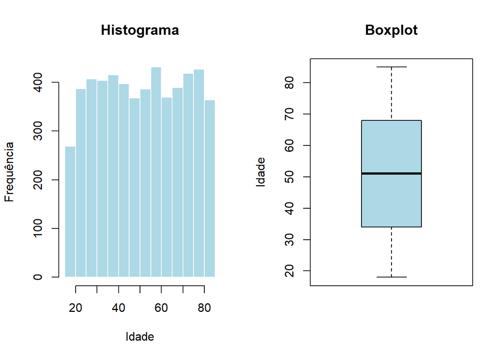

*2.2 “Gender”* **Classificação:** Variável Qualitativa Nominal (dicotómica).)

**Justificação:** Por se tratar de uma variável categórica sem ordem, a sua caracterização baseia-se na análise de frequências absolutas e relativas. O gráfico de barras é a representação mais adequada para comparar as proporções entre as duas categorias e avaliar o equilíbrio da amostra.

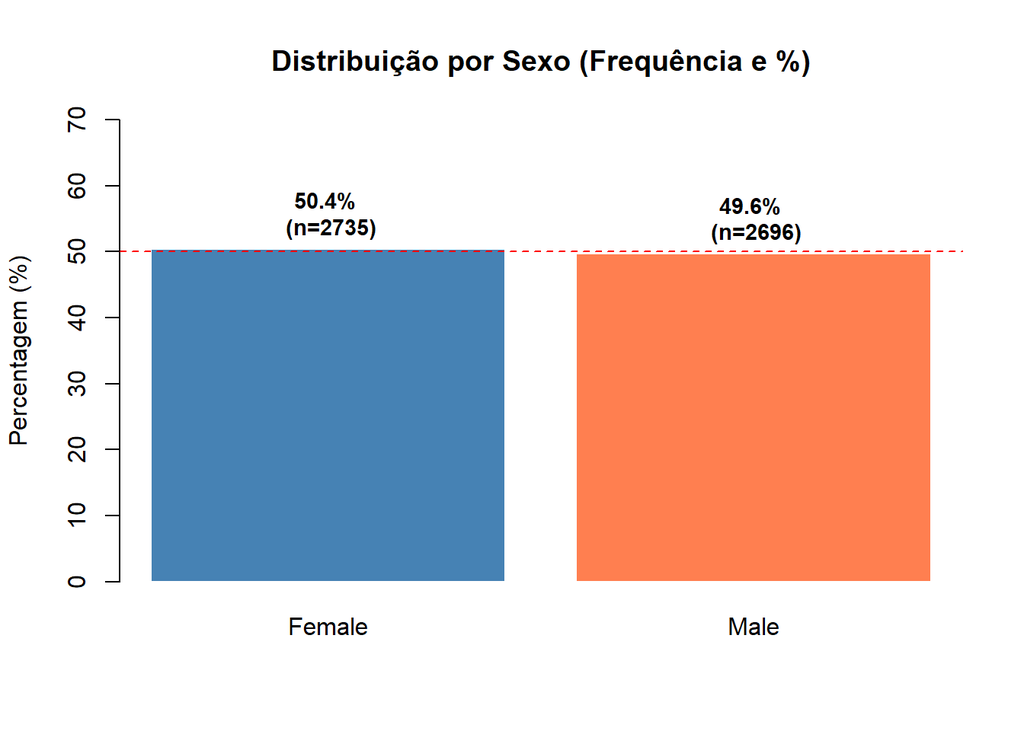

**Exploração** A amostra é constituída por 2735 pacientes do sexo feminino (50.4%) e 2696 do sexo masculino (49.6%). A proximidade entre as frequências relativas das duas categorias indica uma distribuição equilibrada, não se observando predominância relevante de um dos sexos na amostra.

*2.3 “Blood.Type”* **Classificação:** Variável Qualitativa Nominal (Politómica).

**Justificação:** Por se tratar de uma variável categórica sem ordem, a sua caracterização baseia-se na análise de frequências absolutas e relativas. Recorreu-se a um gráfico de barras ordenado, permitindo uma comparação visual direta entre as frequências dos diferentes grupos sanguíneos e a identificação da categoria mais prevalente.

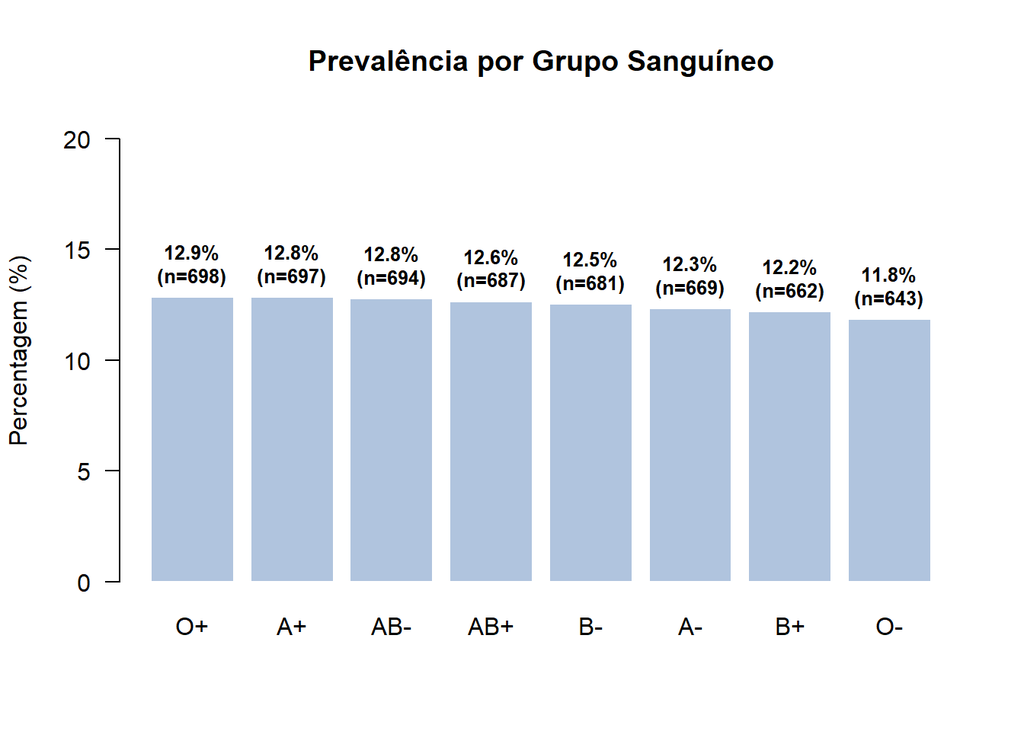

**Exploração** A variável apresenta oito categorias distintas correspondentes aos diferentes grupos sanguíneos. O grupo O+ é o mais frequente na amostra, com 698 pacientes (12.9%), enquanto o grupo O− apresenta a menor frequência, com 643 pacientes (11.8%). As frequências relativas dos diferentes grupos são próximas entre si, não se observando uma predominância marcada de um grupo sanguíneo face aos restantes.

*2.4 “Medical.Condition”* **Classificação:** Variável Qualitativa Nominal

**Justificação:** Recorreu-se a um gráfico de barras horizontal, que permite uma leitura clara das diferentes patologias, evita a sobreposição de texto e, através da ordenação decrescente, facilita a comparação da prevalência entre as várias condições clínicas.

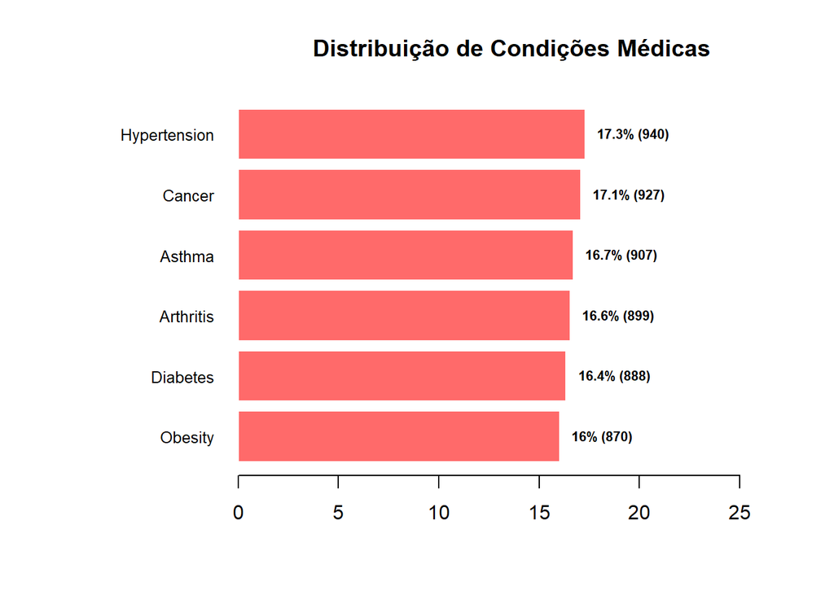

**Exploração** A amostra inclui diversas patologias, sendo a condição médica mais frequente a Hypertension, diagnosticada em 940 pacientes (17.3%). A condição com menor frequência é a Obesity, com 870 casos (16.0%). As frequências relativas observadas são próximas entre si, sugerindo um equilíbrio relativo na distribuição das condições médicas na amostra analisada.

# Pergunta 3

Foi criada a variável `Days_Stay`, que calcula o período de internamento através da diferença entre a data de alta (`Discharge.Date`) e a data de admissão (`Date.of.Admission`).

Metricas de Internamento por Tipo de Admissao

| Tipo de Admissao | Media | Desvio Padrao |
| --- | --- | --- |
| Elective | 15.60 | 8.52 |
| Emergency | 15.63 | 8.58 |
| Urgent | 15.63 | 8.70 |

Após a criação da variável `Days_Stay` procedeu-se à comparação da sua variabilidade de acordo com o tipo de admissão. As médias do número de dias internados são semelhantes entre os três grupos, situando-se em torno de 15.6 dias. A análise do desvio-padrão evidencia diferenças na variabilidade, sendo o grupo Urgent o que apresenta maior dispersão dos dias de internamento (desvio-padrão de 8.70 dias), seguido dos grupos Emergency e Elective. Estes resultados indicam que, embora a duração média do internamento seja semelhante entre os tipos de admissão, a variabilidade é ligeiramente superior nos casos urgentes.

# Pergunta 4.

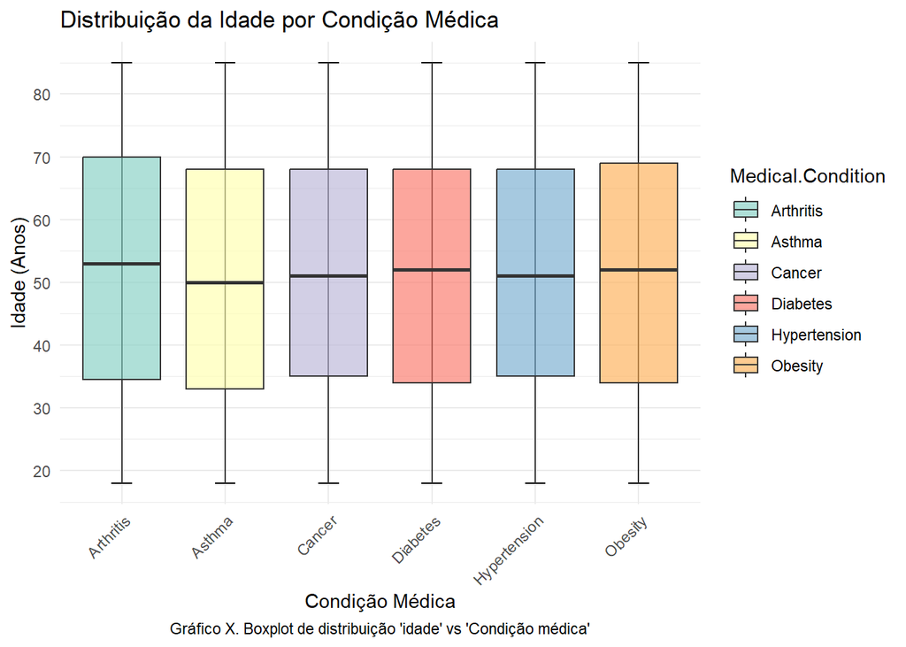

Para comparar a distribuição da idade entre as diferentes categorias da condição médica, recorreu-se a boxplots, uma vez que esta representação gráfica permite analisar simultaneamente a mediana, a dispersão (intervalo interquartil) e a presença de valores extremos em cada grupo. A comparação visual dos boxplots indica que a distribuição etária é abrangente e semelhante entre as diferentes condições médicas. A condição Arthritis apresenta a mediana e o terceiro quartil mais elevados, sugerindo uma maior concentração de pacientes em idades mais avançadas. Por outro lado, a condição Asthma evidencia um primeiro quartil mais baixo, indicando a presença de pacientes mais jovens. O intervalo interquartil é visualmente semelhante entre os grupos, assim como os valores mínimos e máximos observados, não se verificando diferenças marcadas na amplitude etária entre as diferentes condições médicas.

# Pergunta 5

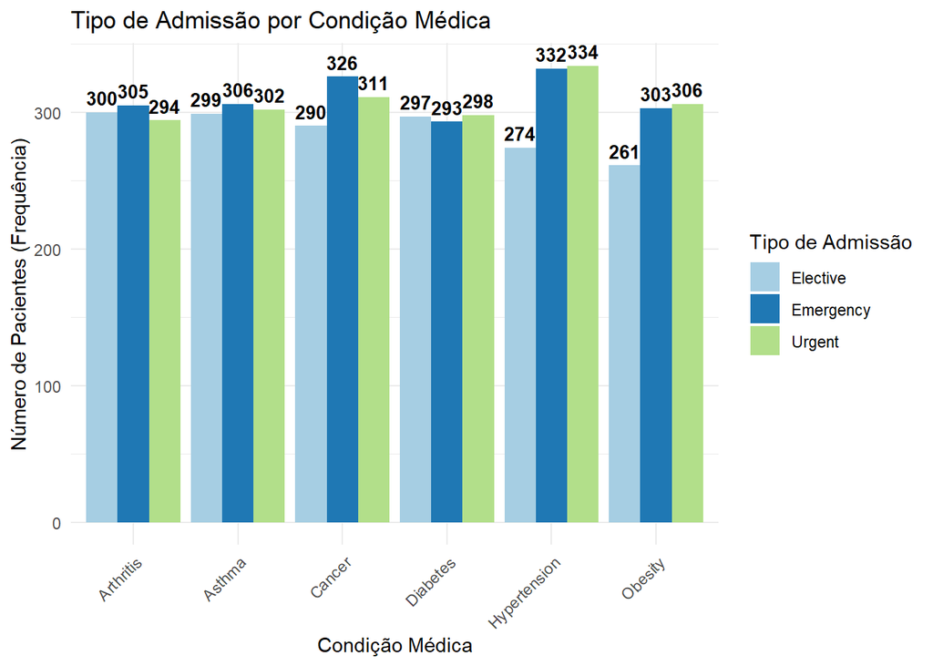

A análise do gráfico indica que, para todas as condições médicas, os três tipos de admissão apresentam frequências semelhantes, não se observando diferenças acentuadas entre categorias. Em algumas patologias, como Hypertension e Cancer, verifica-se uma ligeira predominância das admissões emergentes e urgentes face às eletivas, embora o padrão global sugira uma distribuição relativamente equilibrada dos tipos de admissão entre as diferentes condições médicas.

# Pergunta 6

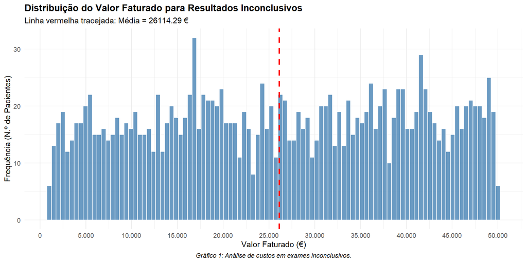

```r
# 1. Garantir a filtragem
dados_inconclusivos <- subset(amostra, Test.Results == "Inconclusive")
library(ggplot2)
library(scales)

# 1. Filtragem dos dados (apenas resultados inconclusivos)
dados_inconclusivos <- subset(amostra, Test.Results == "Inconclusive")

# 2. Cálculo da média faturada para este grupo
media_val <- mean(dados_inconclusivos$Billing.Amount, na.rm = TRUE)

# 3. Elaboração do Gráfico
ggplot(dados_inconclusivos, aes(x = Billing.Amount)) +
  # Histograma com 30 classes e cor steelblue
  geom_histogram(bins = 100, fill = "steelblue", color = "white", alpha = 0.8) +

  # Linha vertical da média
  geom_vline(aes(xintercept = media_val), color = "red",
             linetype = "dashed", linewidth = 1) +

  # Formatação do eixo X com separador de milhar e decimal
  scale_x_continuous(breaks = seq(0, 50000, 5000),
                     labels = comma_format(big.mark = ".", decimal.mark = ",")) +

  # Títulos e legendas
  labs(title = "Distribuição do Valor Faturado para Resultados Inconclusivos",
       subtitle = paste("Linha vermelha tracejada: Média =", round(media_val, 2), "€"),
       x = "Valor Faturado (€)",
       y = "Frequência (N.º de Pacientes)",
       caption = "Gráfico 1: Análise de custos em exames inconclusivos.") +

  # Estética visual
  theme_minimal() +
  theme(plot.title = element_text(face = "bold"),
        plot.caption = element_text(hjust = 0.5, face = "italic"))
```

```r
# Cálculo das métricas para a caracterização
summary(dados_inconclusivos$Billing.Amount)
```

```
##    Min. 1st Qu.  Median    Mean 3rd Qu.    Max.
##    1009   14433   26201   26114   38505   49995
```

```r
sd(dados_inconclusivos$Billing.Amount)
```

```
## [1] 14083.96
```

A distribuição do valor faturado (Billing.Amount) para os pacientes com resultado inconclusivo apresenta uma elevada dispersão, com valores a variarem aproximadamente entre 1 000 e 50 000 unidades monetárias. A média situa-se em torno de 26 114, sendo próxima da mediana (26 201), o que sugere uma distribuição relativamente equilibrada em termos de tendência central.

A análise do histograma não evidencia a presença de picos pronunciados ou de um valor de faturação dominante, indicando que os custos associados a episódios com resultados inconclusivos se distribuem de forma ampla ao longo de todo o intervalo observado. O elevado desvio-padrão reforça a existência de grande variabilidade nos valores faturados.

Em termos interpretativos, estes resultados sugerem que, para casos com testes inconclusivos, não se observa um patamar de custo específico associado, verificando-se uma ampla diversidade de valores de faturação.

# Pergunta 7

```
## Análise de Inferência:
```

```
## n = 1063
```

```
## Média amostral = 15.57
```

```
## IC 98% = [ 14.96 ; 16.18 ]
```

Para os pacientes do sexo masculino que tomam aspirina ou ibuprofeno, procedeu-se à estimação da média do número de dias de internamento com base numa abordagem inferencial. A estimativa pontual da média amostral é de 15.57 dias, calculada a partir de uma amostra com 1063 observações.

Assumindo a independência das observações e recorrendo ao Teorema do Limite Central, foi construído um intervalo de confiança a 98% para a média populacional do número de dias de internamento. O intervalo obtido é [14.96 ; 16.18] dias.

Este resultado indica que, com um nível de confiança de 98%, a média populacional do número de dias de internamento para pacientes do sexo masculino medicados com aspirina ou ibuprofeno se encontra compreendida entre aproximadamente 15 e 16 dias.

# Pergunta 8

```
## Média Amostral: 26377.31
```

```
## Estatística t: -5.75
```

```
## n: 521
```

```
## p-value: p < .001
```

Para as pacientes do sexo feminino medicadas com Lipitor (n = 521), procedeu-se à realização de um teste t para uma amostra, com o objetivo de avaliar se o valor médio faturado difere do valor de referência de 30 000 $.

A média amostral observada foi de 26 377,31 €. O teste estatístico revelou uma diferença estatisticamente significativa relativamente ao valor de referência (t = −5,75; p < .001), indicando que o valor médio faturado neste subgrupo é significativamente diferente de 30 000 €, sendo inferior ao valor considerado.

# Pergunta 9

```
## --- Teste de Associação ---
```

```
## Tamanho da amostra (n):  5431
```

```
## Estatística Chi-squared: 14.03
```

```
## p-value: 0.447
```

A análise inferencial foi efetuada através do teste do Qui-Quadrado de independência de Pearson. O teste não revelou evidência estatisticamente significativa de associação entre o tipo de sangue e o tipo de admissão (χ² = 14.03, n = 5431, p = .447).

Estes resultados indicam que, na amostra analisada, a distribuição do tipo de admissão é semelhante entre os diferentes grupos sanguíneos, não se observando uma associação estatisticamente significativa entre as duas variáveis.

# Pergunta 10

Considerando apenas os pacientes com resultados válidos dos exames na admissão (Normal ou Anormal), a análise foi realizada sobre uma amostra de 3682 indivíduos. A relação entre o sexo e o resultado do teste foi avaliada através de uma análise de dados categóricos, recorrendo a uma tabela de contingência com frequências relativas e ao teste do Qui-Quadrado de independência de Pearson, com correção de continuidade de Yates.

```
##        TESTE DE ASSOCIAÇÃO: ITEM 10
```

```
##        Dimensão da Amostra (n) = 3682
```

```
##
##  Pearson's Chi-squared test with Yates' continuity correction
##
## data:  table(dados_10$Gender, dados_10$Test.Results)
## X-squared = 3.3148, df = 1, p-value = 0.06866
```

```
##
## --- Distribuição Percentual por Género ---
```

```
##
##          Abnormal Normal
##   Female    50.19  49.81
##   Male      53.24  46.76
```

Os resultados do teste não evidenciaram uma associação estatisticamente significativa entre o sexo e o resultado do teste clínico (χ² = 3.31, df = 1, p = .069). A análise descritiva das frequências relativas indica que as proporções de resultados anormais são semelhantes entre homens e mulheres.

Assim, para um nível de significância de 5%, não se encontrou evidência estatisticamente significativa de associação entre o sexo do paciente e o resultado do teste na admissão.

# Pergunta 11

A relação entre a idade (Age) e o número de dias de internamento (Days_Stay) foi avaliada através do coeficiente de correlação de Pearson, uma vez que ambas as variáveis são quantitativas. A análise foi realizada sobre uma amostra de 5431 pacientes.

```
##        ANÁLISE DE CORRELAÇÃO: ITEM 11
```

```
##        Dimensão da Amostra (n) = 5431
```

```
##
##  Pearson's product-moment correlation
##
## data:  amostra$Age and amostra$Days_Stay
## t = -0.67666, df = 5429, p-value = 0.4987
## alternative hypothesis: true correlation is not equal to 0
## 95 percent confidence interval:
##  -0.03577098  0.01741769
## sample estimates:
##          cor
## -0.009183138
```

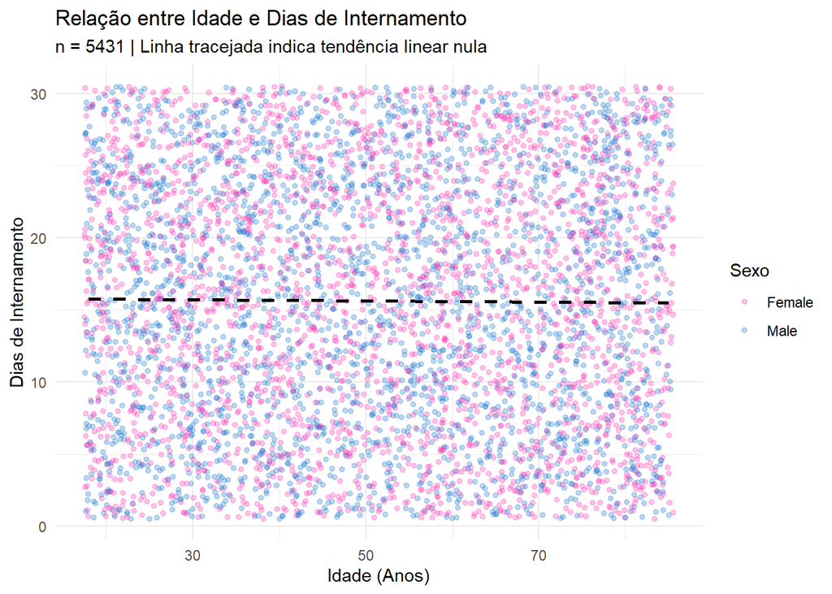

O coeficiente de correlação obtido foi r = −0.009, não sendo estatisticamente significativo (p = .499). O intervalo de confiança a 95% para o coeficiente de correlação inclui o valor zero, reforçando a inexistência de uma associação linear entre as variáveis.

O diagrama de dispersão, com diferenciação por sexo, não evidencia padrões distintos entre homens e mulheres, nem uma tendência linear clara entre a idade e o número de dias de internamento. Assim, não se encontrou evidência estatística de correlação entre a idade do paciente e a duração do internamento na amostra analisada.

# Pergunta 12

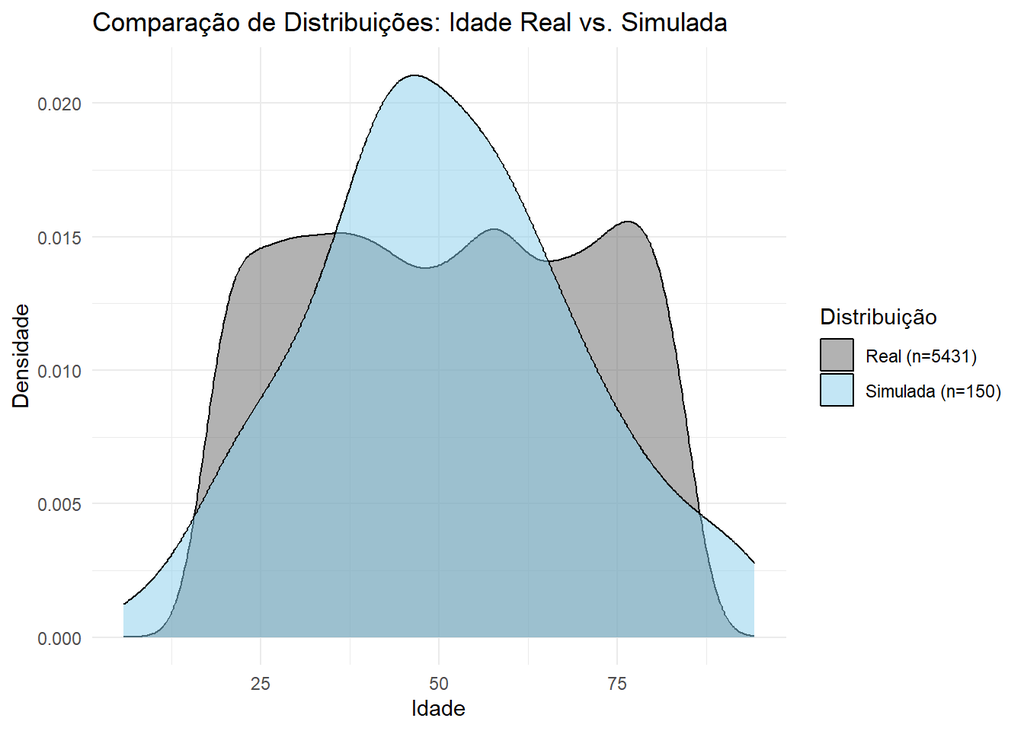

#pergunta 13

**Questão A: “Questão A: Existe associação entre a Condição Médica e o Género?”**

*Objetivo: Verificar se certas doenças (como Diabetes ou Hipertensão) são mais prevalentes num dos sexos nesta amostra.*

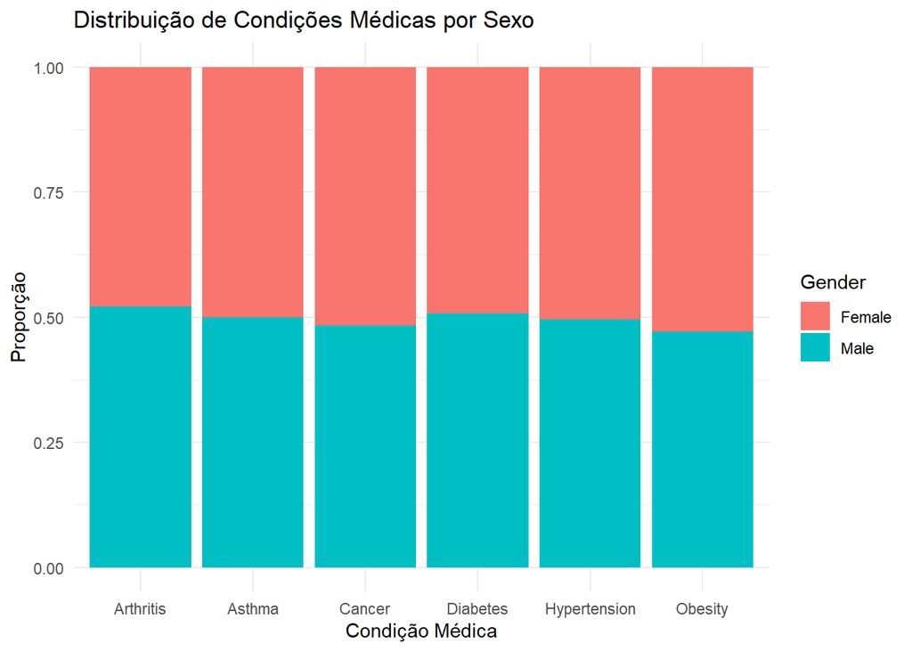

A análise suplementar procurou verificar se a condição médica de admissão estava associada ao sexo do paciente. O teste Qui-Quadrado revelou um $p = 0.364$, indicando que não existe uma associação significativa. Isto sugere que, nesta base de dados, a probabilidade de um paciente ser admitido com uma determinada condição (ex: Asma ou Cancro) é idêntica para homens e mulheres.